# Loading the dataset:

This kaggle dataset is of popular Spotify tracks with over 60,000 songs. It has popular songs from 6 different languages such as English, Hindi, Tamil, Telugu (my mother tongue!), Malyalam and Korean. The dataset has several columns some of which include the track name, the year of release, the popularity of the song, the name of the album, the language, and the tempo to name a few.

```python
import pandas as pd
spotify_data = pd.read_csv('spotify_tracks.csv')

#this is just for a check:
print(spotify_data.head())
print(spotify_data.describe())
```

```
                 track_id                                  track_name  \
0  2r0ROhr7pRN4MXDMT1fEmd                  Leo Das Entry (From "Leo")
1  4I38e6Dg52a2o2a8i5Q5PW                                AAO KILLELLE
2  59NoiRhnom3lTeRFaBzOev      Mayakiriye Sirikiriye - Orchestral EDM
3  5uUqRQd385pvLxC8JX3tXn    Scene Ah Scene Ah - Experimental EDM Mix
4  1KaBRg2xgNeCljmyxBH1mo  Gundellonaa X I Am A Disco Dancer - Mashup

                                         artist_name  year  popularity  \
0                                Anirudh Ravichander  2024          59
1  Anirudh Ravichander, Pravin Mani, Vaishali Sri...  2024          47
2           Anirudh Ravichander, Anivee, Alvin Bruno  2024          35
3  Anirudh Ravichander, Bharath Sankar, Kabilan, ...  2024          24
4  Anirudh Ravichander, Benny Dayal, Leon James, ...  2024          22

                                         artwork_url  \
0  https://i.scdn.co/image/ab67616d0000b273ce9c65...
1  https://i.scdn.co/image/ab67616d0000b273be1b03...
2  https://i.scdn.co/image/ab67616d0000b27334a1dd...
3  https://i.scdn.co/image/ab67616d0000b27332e623...
4  https://i.scdn.co/image/ab67616d0000b2735a59b6...

                                   album_name  acousticness  danceability  \
0                  Leo Das Entry (From "Leo")        0.0241         0.753
1                                AAO KILLELLE        0.0851         0.780
2      Mayakiriye Sirikiriye (Orchestral EDM)        0.0311         0.457
3    Scene Ah Scene Ah (Experimental EDM Mix)        0.2270         0.718
4  Gundellonaa X I Am a Disco Dancer (Mashup)        0.0153         0.689

   duration_ms  ...   key  liveness  loudness  mode  speechiness    tempo  \
0      97297.0  ...   8.0    0.1000    -5.994   0.0       0.1030  110.997
1     207369.0  ...  10.0    0.0951    -5.674   0.0       0.0952  164.995
2      82551.0  ...   2.0    0.0831    -8.937   0.0       0.1530  169.996
3     115831.0  ...   7.0    0.1240   -11.104   1.0       0.4450  169.996
4     129621.0  ...   7.0    0.3450    -9.637   1.0       0.1580  128.961

   time_signature  valence                                          track_url  \
0             4.0    0.459  https://open.spotify.com/track/2r0ROhr7pRN4MXD...
1             3.0    0.821  https://open.spotify.com/track/4I38e6Dg52a2o2a...
2             4.0    0.598  https://open.spotify.com/track/59NoiRhnom3lTeR...
3             4.0    0.362  https://open.spotify.com/track/5uUqRQd385pvLxC...
```

[output cut: 34 more lines]

```
min   -100000.000000     -1.000000     -1.000000     -1.000000
25%       -10.727000      0.000000      0.036700     95.942000
50%        -7.506000      1.000000      0.048900    117.991000
75%        -5.456000      1.000000      0.089100    135.081000
max         1.233000      1.000000      0.959000    239.970000

       time_signature       valence
count    62317.000000  62317.000000
mean         3.857086      0.495226
std          0.502660      0.264787
min         -1.000000     -1.000000
25%          4.000000      0.292000
50%          4.000000      0.507000
75%          4.000000      0.710000
max          5.000000      0.995000
```

# Exploratory data analysis & visualization

The output from importing the data and runnning the checks above, lets us derive some information that can be useful to frame questions in the future, and also general information about the dataset which can help us understand it better.

**For example:**

We can see the top 5 tracks and have information about the name of the track and the track ID. We also have the names of the artists that performed the track, the popularity of the track out of 100, the album the track appears in.

We are also given some niche information such as how acoustic the track is and also how loud it is.

# Some questions to frame:

**1. In which year were most tracks released?**

**2. Top 10 artists with most tracks in this dataset?**

**3. What is the average duration of the tracks over the years?**

**4. Which language is the most dominant in this dataset?**

**5. What is the distribution of track popularity? (are there more popular tracks or less popular tracks?)**

**6. Does the danceability of a song have an imapact on its popularity?**

# Mapping the questions as queries:

**To make it easier to understand the data, I thought it would be best to represent the answers to these quesries in the form of graphs, plots, etc.**

(In order to do so, I will be using some of the concepts I have learned from my DS 200 class when it comes to python coding, jupyter notebooks, plotting data, etc.)

```python
import matplotlib.pyplot as plt
```

**1. In which year were most tracks released?**

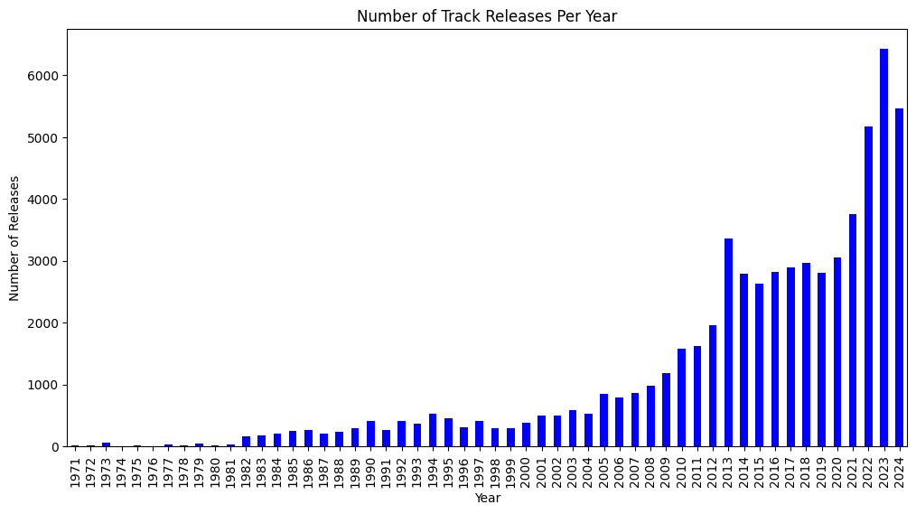

```python
releases_per_year = spotify_data['year'].value_counts().sort_index()

plt.figure(figsize=(12,6))
releases_per_year.plot(kind = 'bar', color = 'blue')
plt.title('Number of Track Releases Per Year')
plt.xlabel('Year')
plt.ylabel('Number of Releases')

plt.show()
```

**2. Top 10 artists with most tracks in this dataset?**

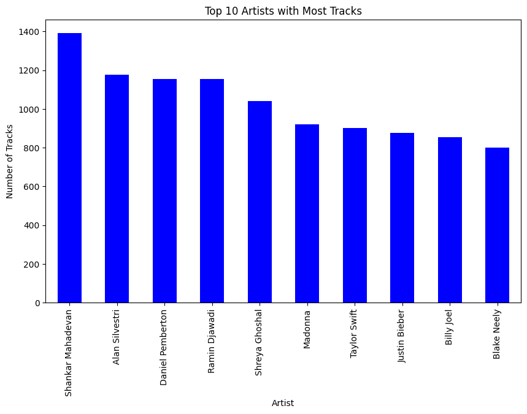

```python
top_artists = spotify_data['artist_name'].value_counts().head(10)

plt.figure(figsize=(10,6))
top_artists.plot(kind = 'bar', color = 'blue')
plt.title('Top 10 Artists with Most Tracks')
plt.xlabel('Artist')
plt.ylabel('Number of Tracks')

plt.show()
```

**3. What is the average duration of tracks over time?**

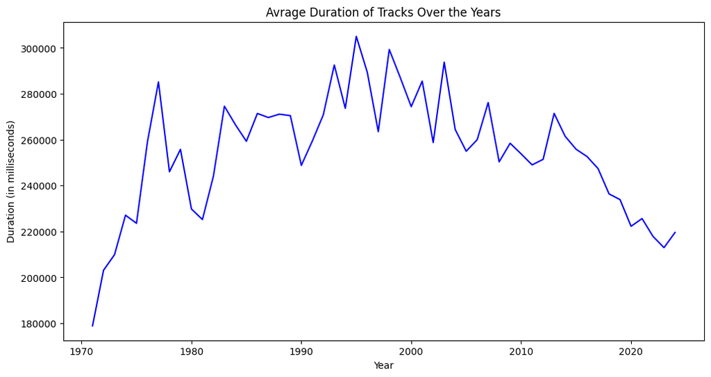

```python
avg_duration = spotify_data.groupby('year')['duration_ms'].mean()

plt.figure(figsize=(12,6))
avg_duration.plot(kind='line', color = 'blue')
plt.title('Avrage Duration of Tracks Over the Years')
plt.xlabel('Year')
plt.ylabel('Duration (in milliseconds)')

plt.show()
```

**4. Which language is the most dominant in this dataset?**

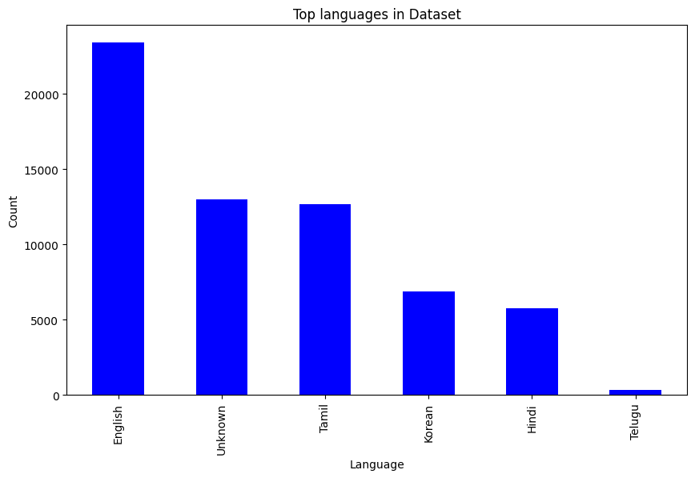

```python
top_lang = spotify_data['language'].value_counts().head(6)

plt.figure(figsize=(10,6))
top_lang.plot(kind = 'bar', color = 'blue')
plt.title('Top languages in Dataset')
plt.xlabel('Language')
plt.ylabel('Count')

plt.show()
```

**5. What is the distribution of track popularity? (Are there more popular tracks or less popular tracks in this dataset?)**

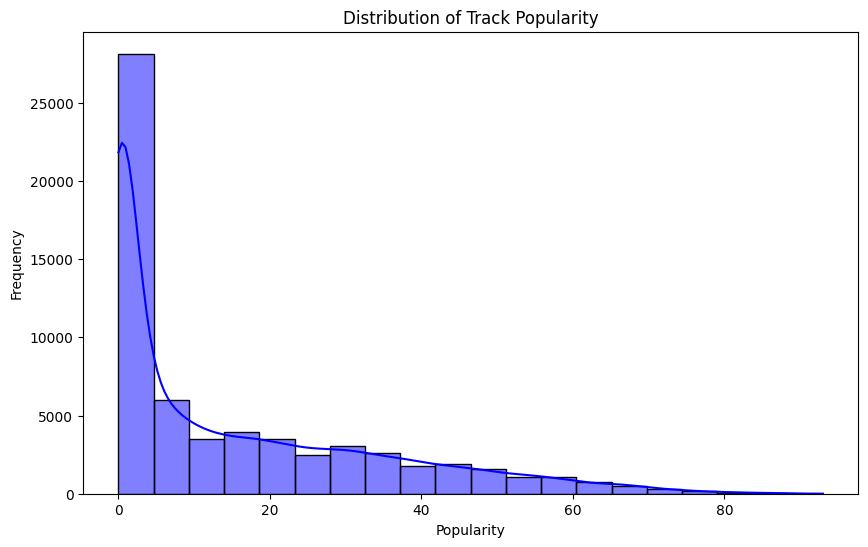

```python
import seaborn as sns

plt.figure(figsize=(10,6))
sns.histplot(spotify_data['popularity'], kde = True, bins = 20, color = 'blue')
plt.title('Distribution of Track Popularity')
plt.xlabel('Popularity')
plt.ylabel('Frequency')

plt.show()
```

**6. Does the danceability of a song have an impact on its popularity?**

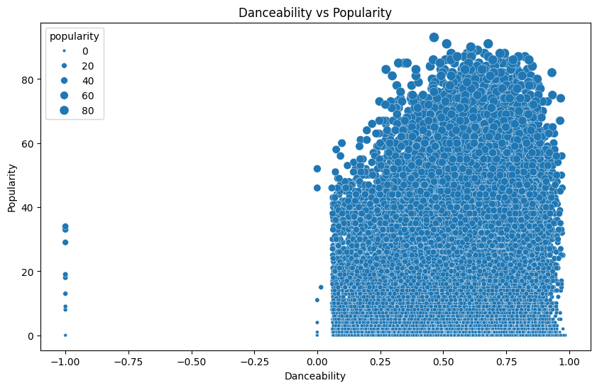

```python
plt.figure(figsize=(10,6))
sns.scatterplot(data = spotify_data, x = 'danceability', y = 'popularity', size = 'popularity', sizes = (10, 100))
plt.title('Danceability vs Popularity')
plt.xlabel('Danceability')
plt.ylabel('Popularity')

plt.show()
```

# Conclusions:

**We can gather multiple insights from the queries we used to generate answers that can be helpful in getting to know the data better**